# GAM_all_variables_different_outcomes

# Research question

How did neonatal health evolve through time (2007-2020)?

Particularly, did it change during two important crisis: the 2009 economic crisis and the current COVID-19 pandemic?

We focus on the evolution of birthweight and gestational age, and on the rates of stillbirth, preterm birth, lowbirth weight and macrosomia babies.

COVID data will be included soon: hospital cases, mortality. Temperature will also maybe be included.

# Data and Methods

## Data

We used data from the Federal Office of Statistics: Bevnat. It covers:

- All births that occurred in Switzerland
- Between 1987 and 2021

## Variables

### Swiss-SEP

Average Swiss neighbourhood index of socioeconomic position (Swiss-SEP 2.0). Swiss-SEP 2.0 indicates the average socioeconomic situation in a municipality. It was developed by the Institute for Social and Preventive Medicine at the University of Bern.

## Exclusions steps

- As gestational age was only recorded systematically from 2007, we analysed data from this year only
- Steps of exclusions: see the ppt

Definitions:

- Preterm birth babies : <37 weeks
- Low birthweight babies : <2500g
- Macrosomia babies: >= 4000g
- “normal” birthweight babies: )2500-4000)

We work with two different datasets:

- one that includes stillbirth cases to investigate stillbirth outcome: bevn_eco_in6.
- one that excludes stillbirth cases to investigate birthweight/gestational age/ preterm birth/ low birth weight/ macrosomia outcomes : bevn_eco_in7.

## Characteristics at inclusion and in two other datasets used

- see tables in html.

## Methods

We built different GAM models, investigating the following outcomes:

- birthweight as a continuous variable
- stillbirth : binary yes/no variable
- gestational age: as a continuous variable, in days
- preterm birth: binary yes/no variable.
- low birthweight: binary yes/no variable, comparing LBW babies vs the rest
- low birthweight: binary yes/no variable, comparing LBW babies vs “normal” birthweight babies
- macrosomia: binary yes/no variable, comparing macrosomia babies vs “normal” birthweight babies

# Birthweight

We chose this model based on lower AIC and also lower k value for maternal age, which seems more appropriate when looking at the graph.

```
##
## Family: gaussian
## Link function: identity
##
## Formula:
## BW ~ s(GA_weeks) + s(mat_age) + s(birth_Y_M_num) + s(month, bs = "cc") +
##     s(mean_ssep2) + s(mean_Alt_mean2) + parity_cat + sex + Urban3 +
##     Language + mother_nationality_cat2 + civil_status3 + HW +
##     GR + COVID_first_wave + COVID_second_wave
##
## Parametric coefficients:
##                                                      Estimate Std. Error  t value Pr(>|t|)
## (Intercept)                                         3345.8814     0.8515 3929.269  < 2e-16 ***
## parity_cat(1,2]                                      123.2663     0.8111  151.974  < 2e-16 ***
## parity_cat(2,3]                                      167.8539     1.2382  135.558  < 2e-16 ***
## parity_cat(3,20]                                     193.7811     2.1373   90.664  < 2e-16 ***
## sex2                                                -146.8488     0.7176 -204.649  < 2e-16 ***
## Urban3                                                -1.7886     0.7722   -2.316   0.0205 *
## LanguageFrench                                       -44.1068     0.9018  -48.912  < 2e-16 ***
## LanguageItalian                                      -69.4002     2.0808  -33.353  < 2e-16 ***
## mother_nationality_cat2Africa                          8.9924     2.1829    4.120  3.8e-05 ***
## mother_nationality_cat2Asia                          -25.5109     1.9835  -12.861  < 2e-16 ***
## mother_nationality_cat2Europe                         28.7795     0.8228   34.977  < 2e-16 ***
## mother_nationality_cat2Northern America               58.5743     4.6997   12.463  < 2e-16 ***
## mother_nationality_cat2Southern and Central America   40.3484     2.7110   14.883  < 2e-16 ***
## civil_status3Single                                  -33.2759     0.8950  -37.178  < 2e-16 ***
## HW1                                                   -2.6182     3.3606   -0.779   0.4359
## GR1                                                    2.0724     2.5222    0.822   0.4113
## COVID_first_wave1                                     -1.8089     3.6432   -0.497   0.6195
## COVID_second_wave1                                     3.0233     3.0559    0.989   0.3225
## ---
## Signif. codes:  0 '***' 0.001 '**' 0.01 '*' 0.05 '.' 0.1 ' ' 1
##
## Approximate significance of smooth terms:
##                     edf Ref.df         F  p-value
## s(GA_weeks)       8.890  8.994 81533.693  < 2e-16 ***
## s(mat_age)        5.288  6.252    14.102  < 2e-16 ***
## s(birth_Y_M_num)  8.413  8.903    27.549  < 2e-16 ***
## s(month)          4.830  8.000     3.134 3.02e-05 ***
## s(mean_ssep2)     5.131  6.298    13.792  < 2e-16 ***
## s(mean_Alt_mean2) 7.158  8.171   160.750  < 2e-16 ***
## ---
## Signif. codes:  0 '***' 0.001 '**' 0.01 '*' 0.05 '.' 0.1 ' ' 1
##
## R-sq.(adj) =  0.409   Deviance explained = 40.9%
## fREML = 8.751e+06  Scale est. = 1.5227e+05  n = 1184860
```

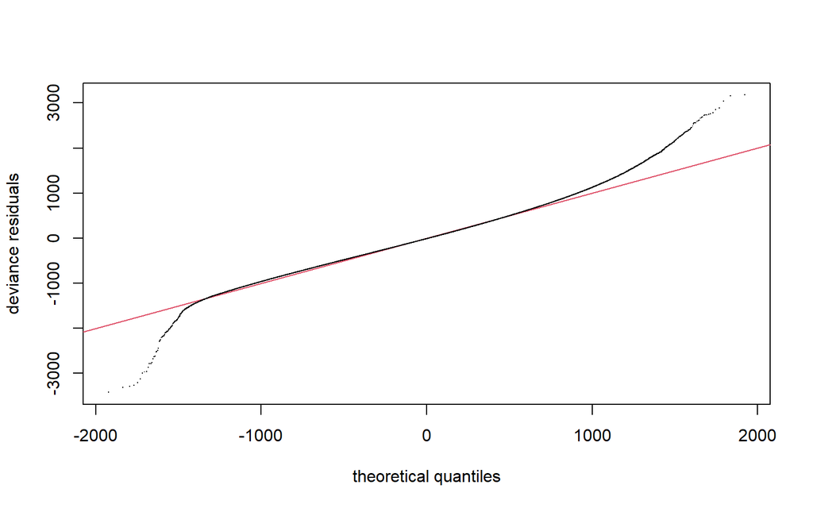

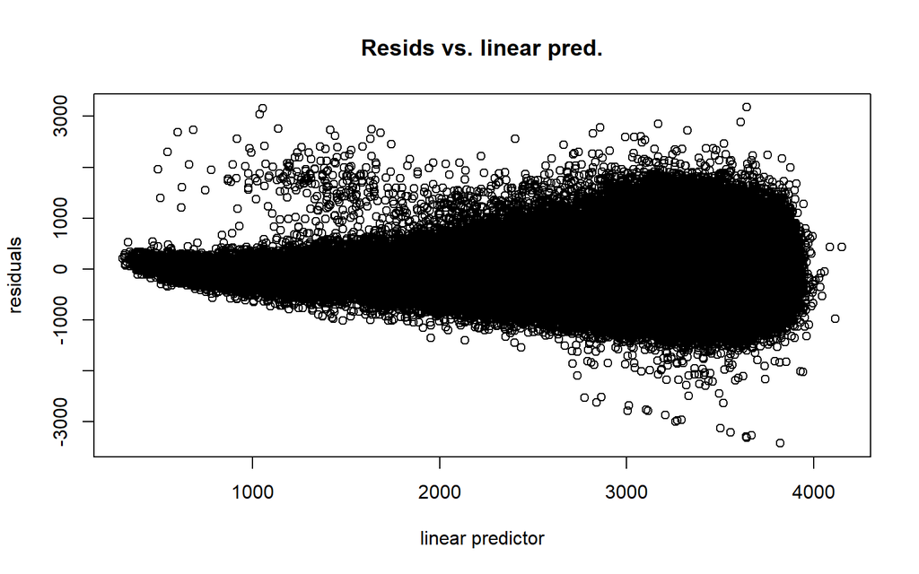

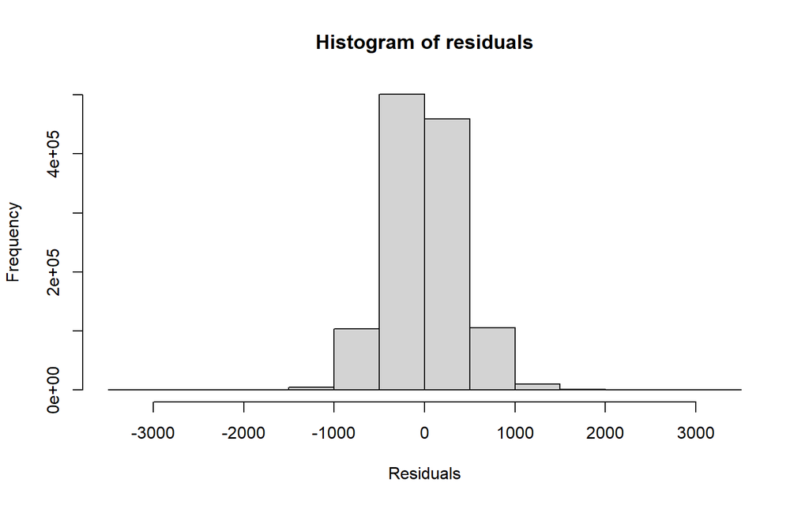

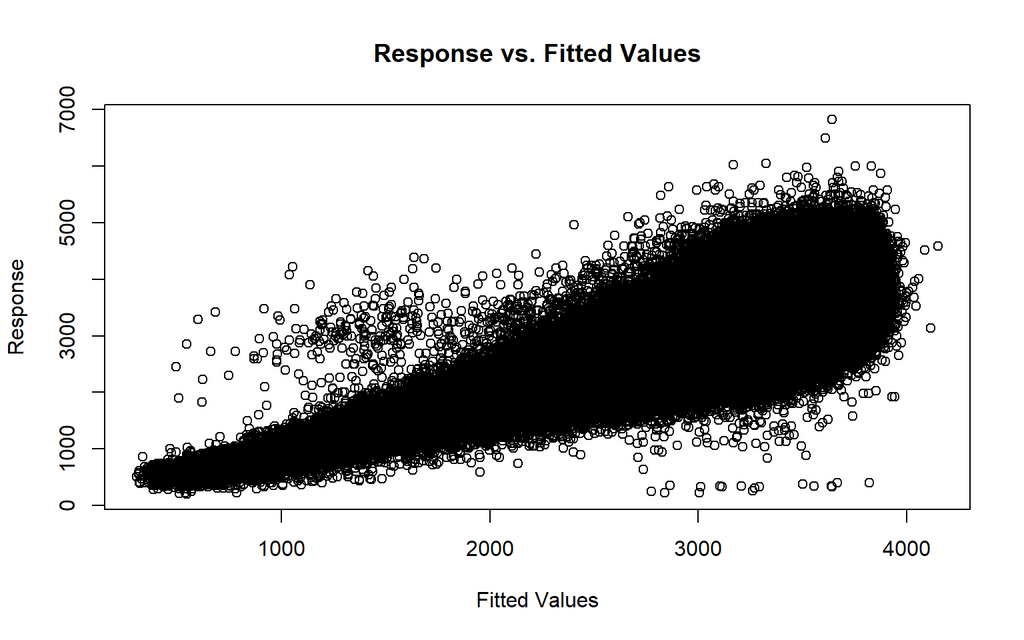

```
##
## Method: fREML   Optimizer: perf newton
## full convergence after 10 iterations.
## Gradient range [-0.02407129,0.0184743]
## (score 8750990 & scale 152270.6).
## Hessian positive definite, eigenvalue range [0.9871862,592418.5].
## Model rank =  71 / 71
##
## Basis dimension (k) checking results. Low p-value (k-index<1) may
## indicate that k is too low, especially if edf is close to k'.
##
##                     k'  edf k-index p-value
## s(GA_weeks)       9.00 8.89    1.01   0.615
## s(mat_age)        9.00 5.29    0.99   0.355
## s(birth_Y_M_num)  9.00 8.41    1.02   0.905
## s(month)          8.00 4.83    1.02   0.905
## s(mean_ssep2)     9.00 5.13    0.98   0.140
## s(mean_Alt_mean2) 9.00 7.16    0.98   0.055 .
## ---
## Signif. codes:  0 '***' 0.001 '**' 0.01 '*' 0.05 '.' 0.1 ' ' 1
```

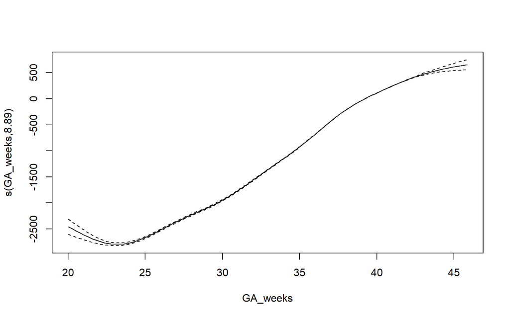

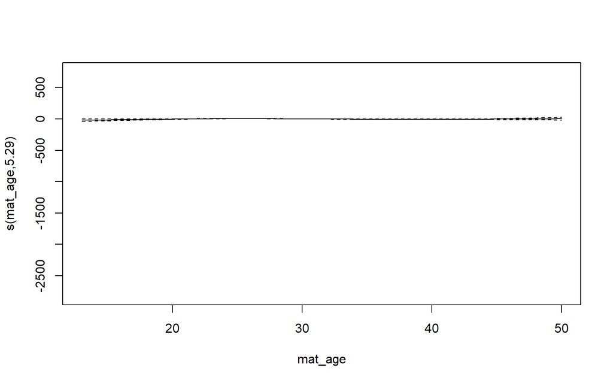

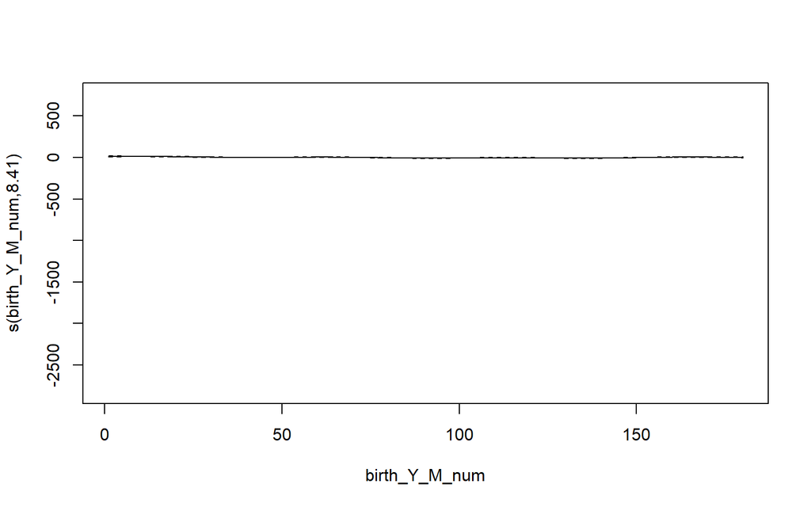

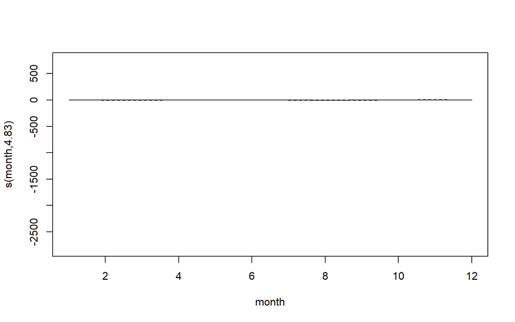

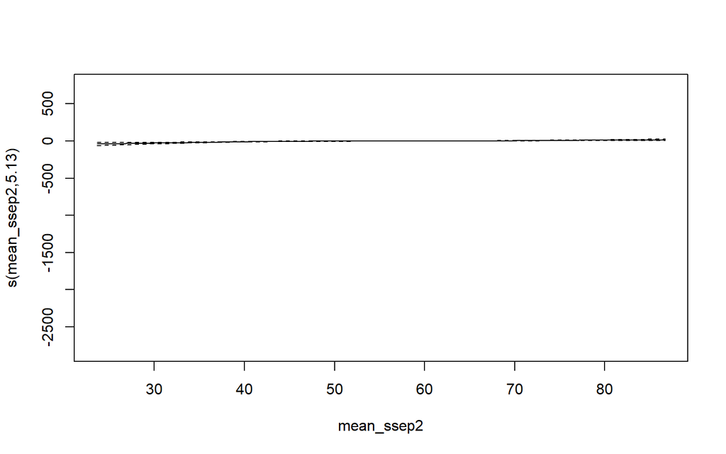

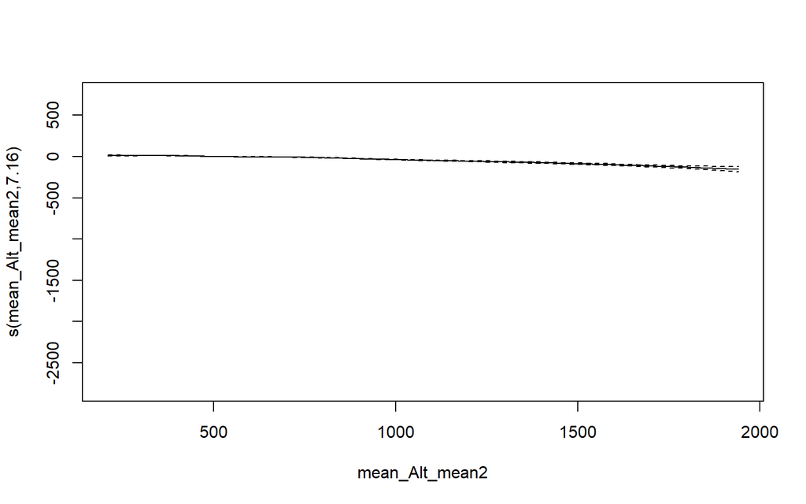

## Graph Gestational age X birthweight

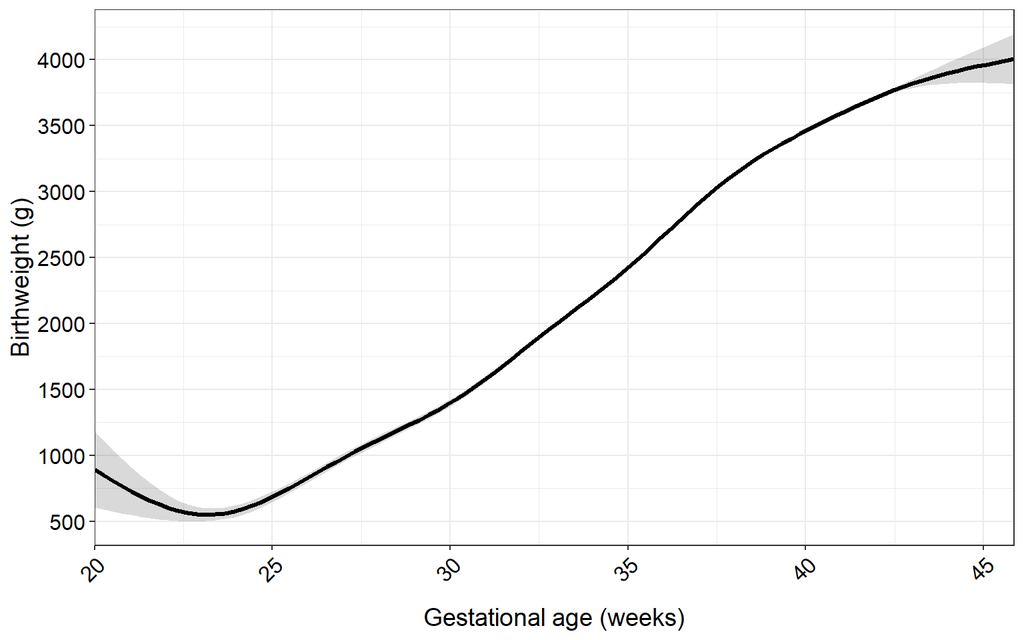

## Graph maternal age variable X BW

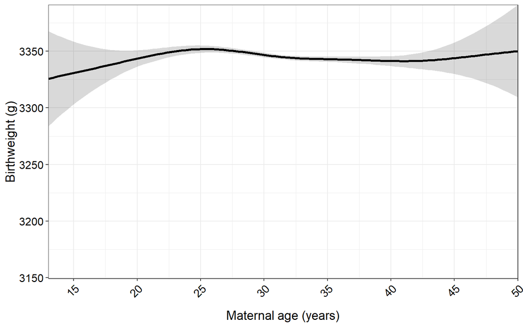

## Graph time X birthweight

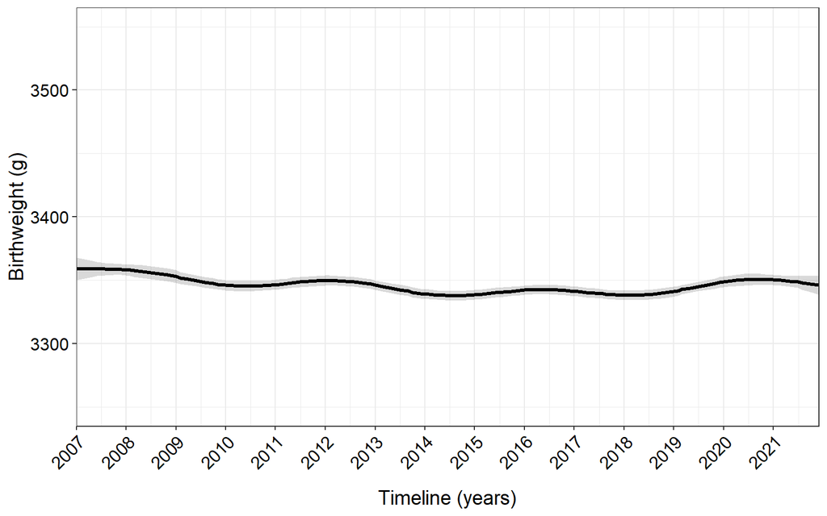

## Graph seasonality X birthweight

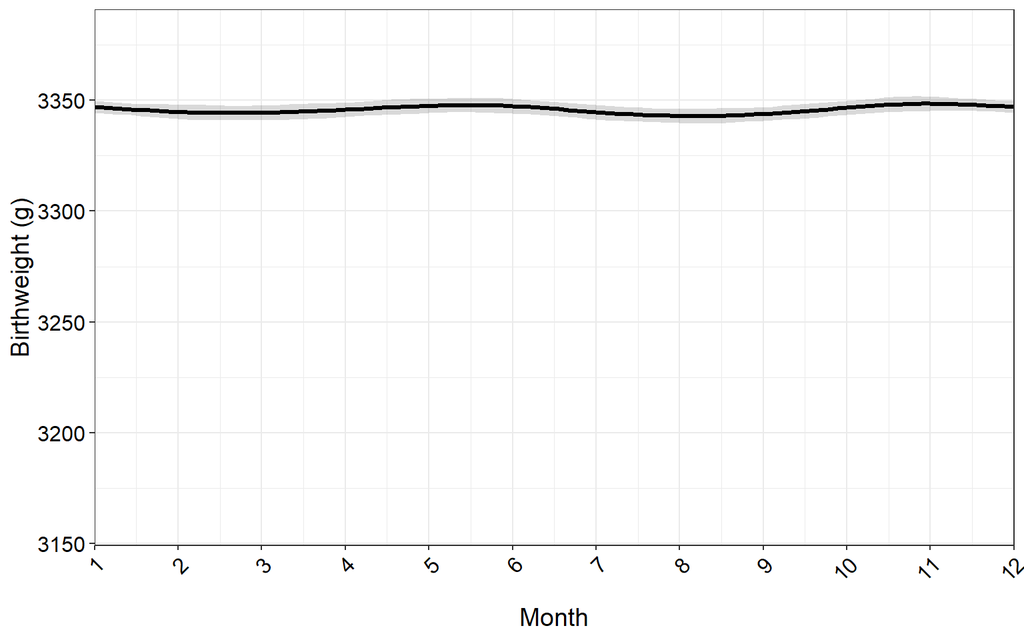

## Graph SSEP X birthweight

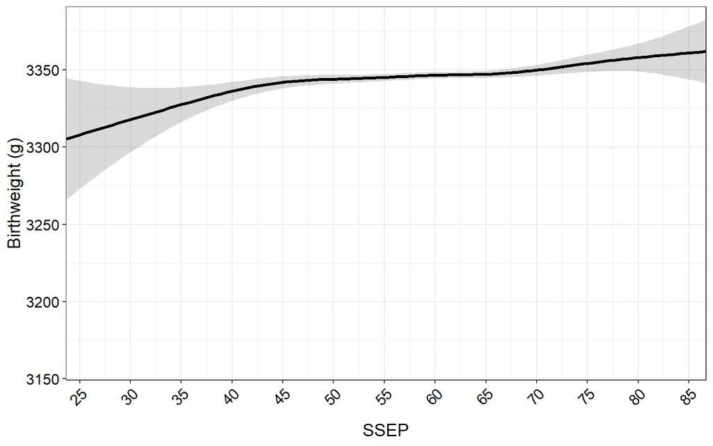

## Graph altitude X birthweight

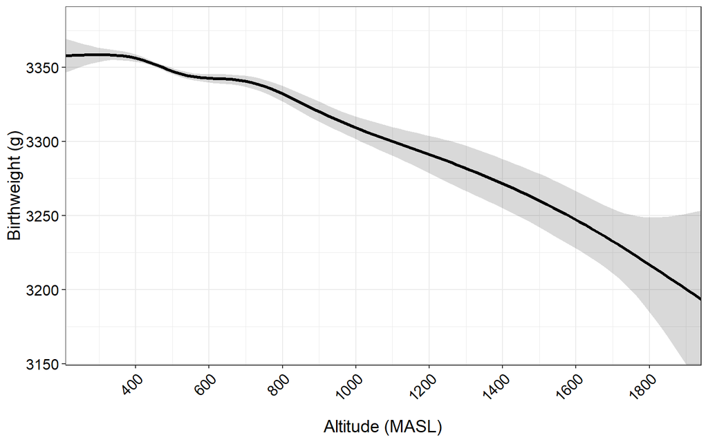

)

Cohen’s d formula:

$d=\frac{beta}{SD}$ and $SD=\sqrt{n}*se$

$d=\frac{beta}{\sqrt{n}*se}$

- beta: estimate
- se: standard error
- n: population/observation size
- SD: standard deviation

## Table summarizing the birthweight outcome model

Birthweight GAM

| variable | category | beta | 95% CI (g) lci | 95% CI (g) uci | d |  |
| --- | --- | --- | --- | --- | --- | --- |
| Intercept |  | 3345.88 | 3344.21 | 3347.55 |  | 3.75 |
| Parity (ref: 1) | 2 | 123.27 | 121.68 | 124.86 | 0.14 |  |
|  | 3 | 167.85 | 165.43 | 170.28 | 0.13 |  |
|  | >3 | 193.78 | 189.59 | 197.97 | 0.09 |  |
| Sex (ref: male) | Female | -146.85 | -148.26 | -145.44 | 0.20 |  |
| Urban (ref: rural) | Urban | -1.79 | -3.31 | -0.27 | 0.00 |  |
| Language region (ref: German) | French | -44.11 | -45.88 | -42.33 | 0.05 |  |
|  | Italian | -69.40 | -73.48 | -65.32 | 0.03 |  |
| Maternal nationality (ref: Swiss) | Africa | 8.99 | 4.71 | 13.27 | 0.00 |  |
|  | Asia | -25.51 | -29.40 | -21.62 | 0.01 |  |
|  | Europe | 28.78 | 27.17 | 30.39 | 0.03 |  |
|  | Northern America | 58.57 | 49.36 | 67.79 | 0.01 |  |
|  | Southern/Central America | 40.35 | 35.03 | 45.66 | 0.01 |  |
| Civil status (ref: married) | Single | -33.28 | -35.03 | -31.52 | 0.04 |  |
| Heatwave (ref: 0) |  | -2.62 | -9.23 | 3.99 | 0.00 |  |
| Great Recession (ref: 0) |  | 2.07 | -2.89 | 7.03 | 0.00 |  |
| COVID first wave (ref: 0) |  | -1.81 | -8.98 | 5.36 | 0.00 |  |
| COVID second wave (ref: 0) |  | 3.02 | -3.01 | 9.06 | 0.00 |  |

# Stillbirth

```
##
## Family: binomial
## Link function: logit
##
## Formula:
## stillbirth ~ s(GA_weeks) + s(mat_age) + s(birth_Y_M_num) + s(month,
##     bs = "cc") + s(mean_ssep2) + s(mean_Alt_mean2) + sex + Urban3 +
##     Language + mother_nationality_cat2 + civil_status3 + HW +
##     GR + COVID_first_wave + COVID_second_wave
##
## Parametric coefficients:
##                                                     Estimate Std. Error  z value Pr(>|z|)
## (Intercept)                                         -7.03150    0.04460 -157.664  < 2e-16 ***
## sex2                                                 0.13568    0.03411    3.978 6.95e-05 ***
## Urban3                                               0.05332    0.03603    1.480  0.13889
## LanguageFrench                                       0.10865    0.04068    2.671  0.00756 **
## LanguageItalian                                     -0.03044    0.09966   -0.305  0.76000
## mother_nationality_cat2Africa                        0.14618    0.08525    1.715  0.08640 .
## mother_nationality_cat2Asia                         -0.05357    0.09255   -0.579  0.56274
## mother_nationality_cat2Europe                        0.02031    0.03880    0.523  0.60069
## mother_nationality_cat2Northern America             -0.36225    0.26320   -1.376  0.16872
## mother_nationality_cat2Southern and Central America -0.15566    0.12535   -1.242  0.21431
## civil_status3Single                                  0.03246    0.03903    0.832  0.40560
## HW1                                                  0.06695    0.15062    0.444  0.65669
## GR1                                                  0.16922    0.09803    1.726  0.08432 .
## COVID_first_wave1                                   -0.11420    0.16945   -0.674  0.50036
## COVID_second_wave1                                   0.05319    0.13634    0.390  0.69645
## ---
## Signif. codes:  0 '***' 0.001 '**' 0.01 '*' 0.05 '.' 0.1 ' ' 1
##
## Approximate significance of smooth terms:
##                     edf Ref.df    Chi.sq p-value
## s(GA_weeks)       7.973  8.475 23834.871 < 2e-16 ***
## s(mat_age)        3.202  4.026    10.455 0.03430 *
## s(birth_Y_M_num)  1.005  1.011     0.797 0.37537
## s(month)          1.832  8.000     6.675 0.01365 *
## s(mean_ssep2)     1.008  1.016     6.862 0.00923 **
## s(mean_Alt_mean2) 4.758  5.842    13.722 0.02998 *
## ---
## Signif. codes:  0 '***' 0.001 '**' 0.01 '*' 0.05 '.' 0.1 ' ' 1
##
## R-sq.(adj) =  0.223   Deviance explained = 40.4%
## fREML = 1.6901e+06  Scale est. = 1         n = 1189309
```

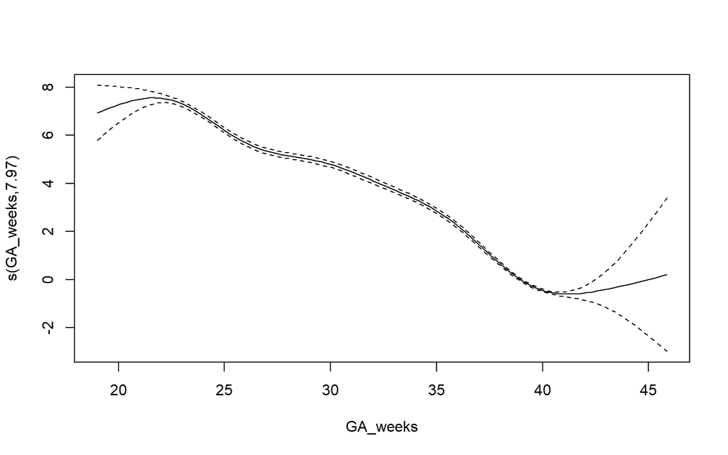

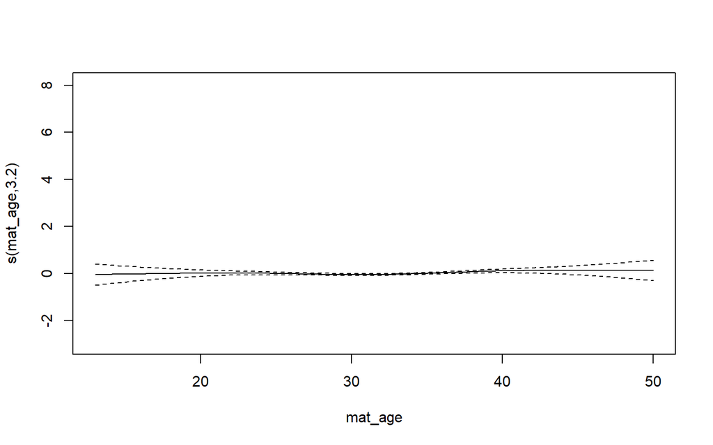

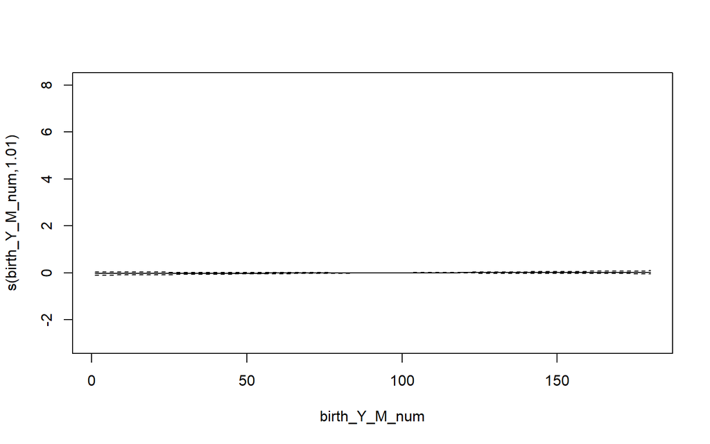

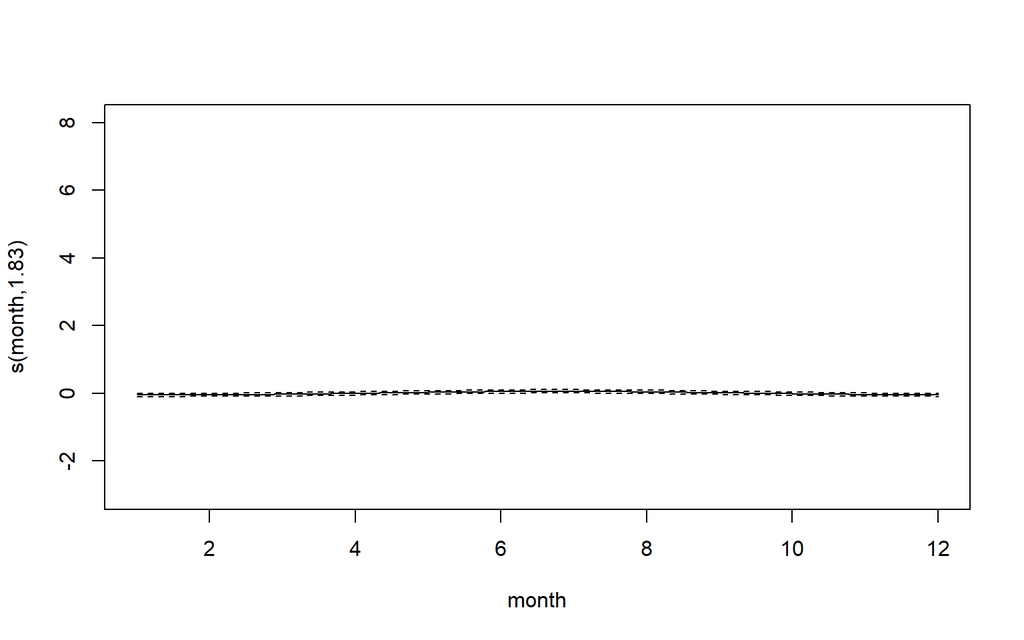

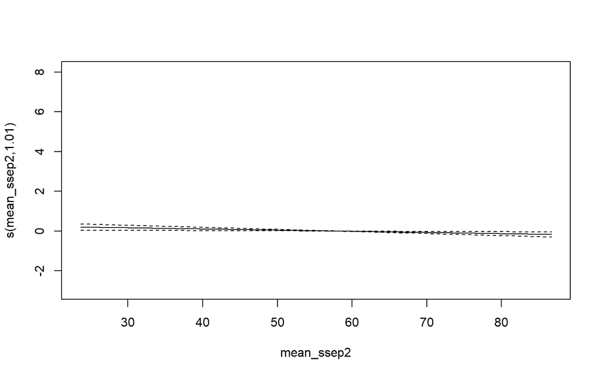

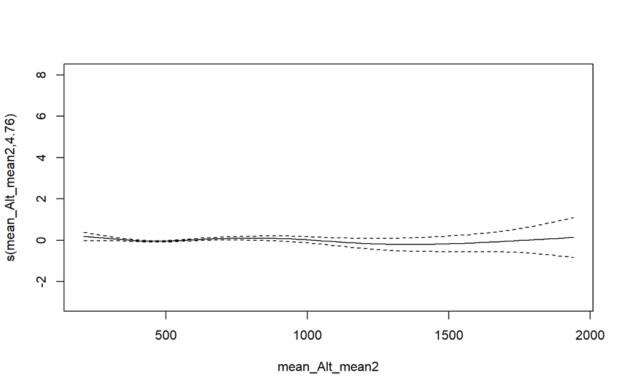

```
##                   k'      edf   k-index p-value
## s(GA_weeks)        9 7.972986 0.9492436   0.060
## s(mat_age)         9 3.201795 0.9659747   0.545
## s(birth_Y_M_num)   9 1.005337 0.9640522   0.365
## s(month)           8 1.831830 0.9658441   0.540
## s(mean_ssep2)      9 1.008124 0.9650089   0.400
## s(mean_Alt_mean2)  9 4.758361 0.9637277   0.305
```

```
##               para s(GA_weeks) s(mat_age) s(birth_Y_M_num)   s(month) s(mean_ssep2)
## worst    0.7588914 0.012298264 0.05785224        0.2984931 0.10234945     0.2685548
## observed 0.7588914 0.006021408 0.01831515        0.1316934 0.07908422     0.2222967
## estimate 0.7588914 0.008032006 0.04160294        0.1253345 0.03193106     0.1389554
##          s(mean_Alt_mean2)
## worst           0.23704400
## observed        0.06026524
## estimate        0.11503718
```

## Graph gestational age X Stillbirth

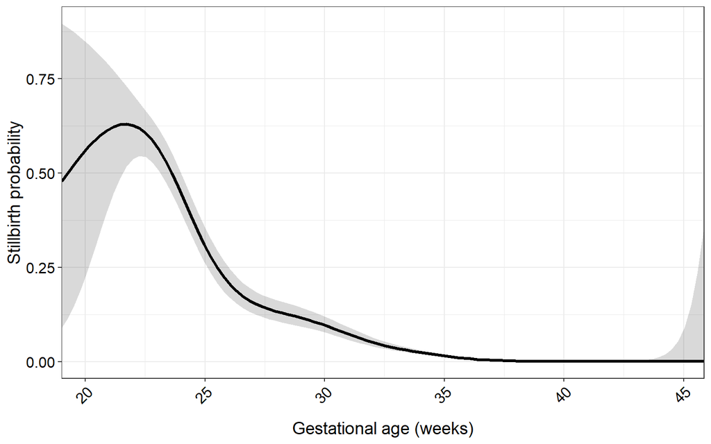

## Graph maternal age X Stillbirth

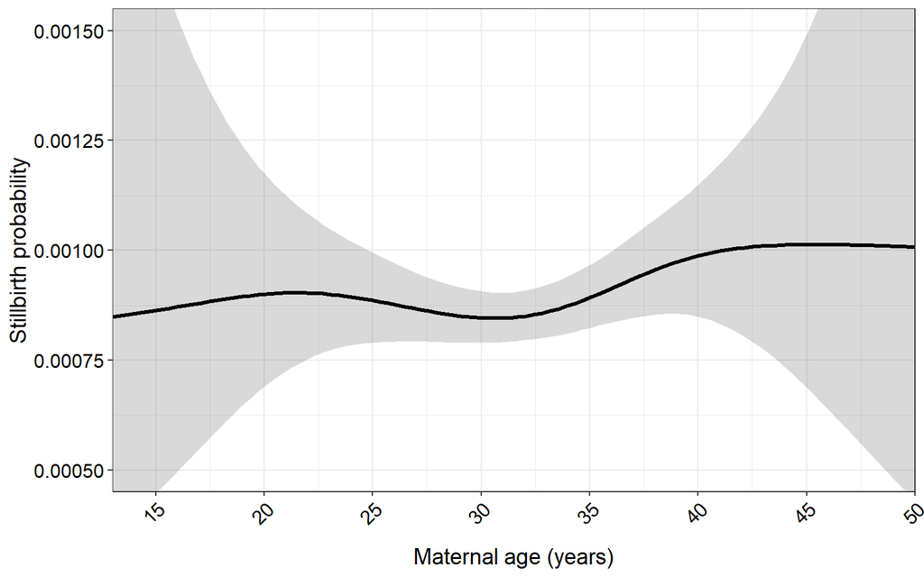

## Graph time X Stillbirth

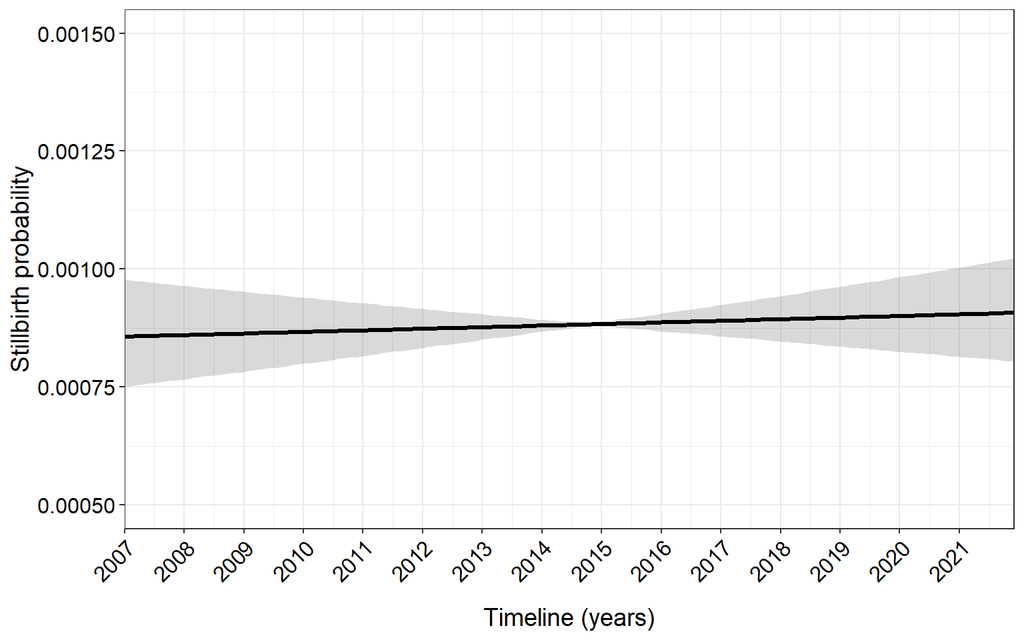

## Graph seasonality X Stillbirth

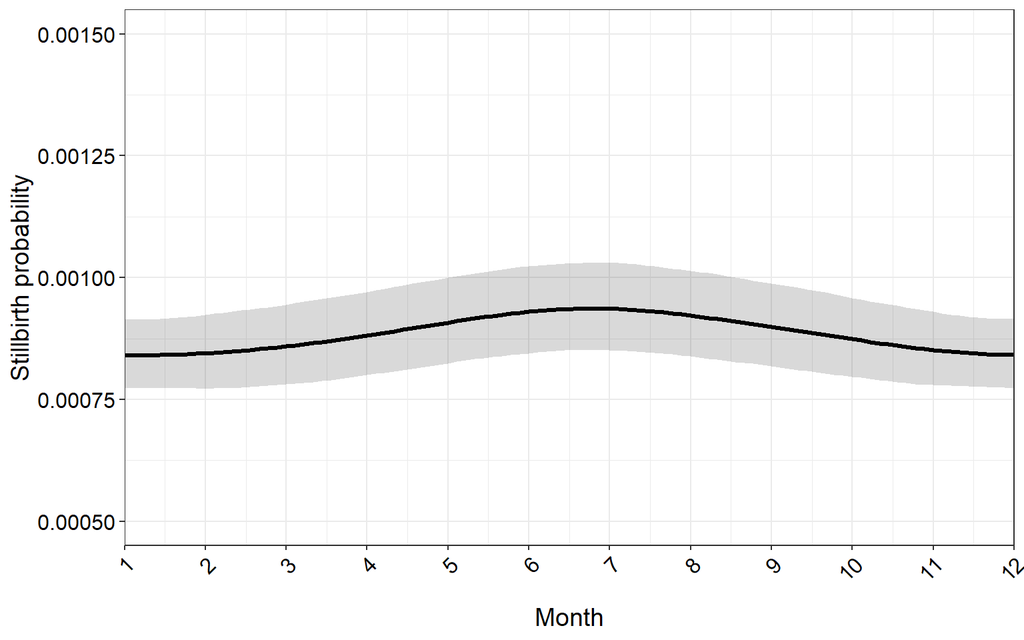

## Graph SSEP X Stillbirth

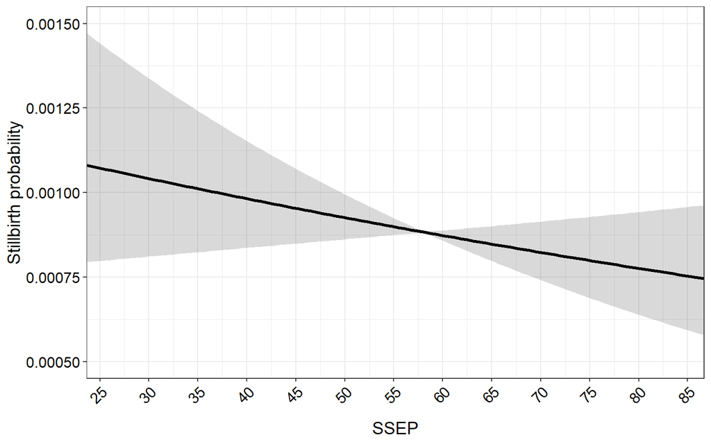

## Graph altitude X Stillbirth

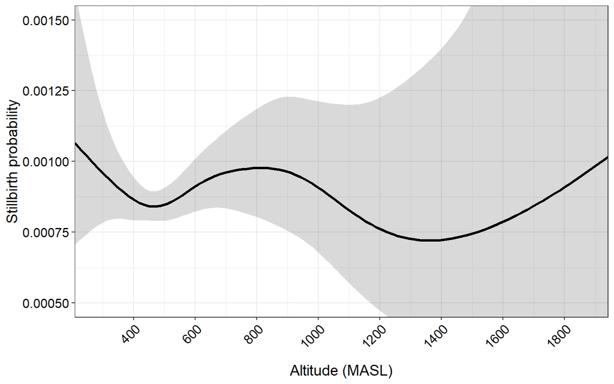

## Table summarizing the stillbirth outcome model

Stillbirth GAM

| variable | category | OR | 95% CI lci | 95% CI uci | d |  |
| --- | --- | --- | --- | --- | --- | --- |
| Intercept |  | 0.00 | 0.00 | 0.00 |  | 3.88 |
| Sex (ref: male) | Female | 1.15 | 1.07 | 1.22 | 0.07 |  |
| Urban (ref: rural) | Urban | 1.05 | 0.98 | 1.13 | 0.03 |  |
| Language region (ref: German) | French | 1.11 | 1.03 | 1.21 | 0.06 |  |
|  | Italian | 0.97 | 0.80 | 1.18 | 0.02 |  |
| Maternal nationality (ref: Swiss) | Africa | 1.16 | 0.98 | 1.37 | 0.08 |  |
|  | Asia | 0.95 | 0.79 | 1.14 | 0.03 |  |
|  | Europe | 1.02 | 0.95 | 1.10 | 0.01 |  |
|  | Northern America | 0.70 | 0.42 | 1.17 | 0.20 |  |
|  | Southern and Central America | 0.86 | 0.67 | 1.09 | 0.09 |  |
| Civil status (ref: married) | Single | 1.03 | 0.96 | 1.12 | 0.02 |  |
| Heatwave (ref: 0) |  | 1.07 | 0.79 | 1.44 | 0.04 |  |
| Great Recession (ref: 0) |  | 1.18 | 0.98 | 1.44 | 0.09 |  |
| COVID first wave (ref: 0) |  | 0.89 | 0.64 | 1.24 | 0.06 |  |
| COVID second wave (ref: 0) |  | 1.05 | 0.81 | 1.38 | 0.03 |  |

Time variable (birth_Y_M_num) and mean ssep variable could have been put as linear terms, because the model including them as smoothed terms showed that the relationship between these and stillbirth was linear, but I chose to keep them as smooth variable to have models that look “more alike” between the different outcomes (birthweight, PTB).

# Preterm birth

```
##
## Family: binomial
## Link function: logit
##
## Formula:
## PTB ~ s(BW) + s(mat_age) + s(birth_Y_M_num) + s(month, bs = "cc") +
##     s(mean_ssep2) + s(mean_Alt_mean2) + parity_cat + sex + Urban3 +
##     Language + mother_nationality_cat2 + civil_status3 + HW +
##     GR + COVID_first_wave + COVID_second_wave
##
## Parametric coefficients:
##                                                     Estimate Std. Error  z value Pr(>|z|)
## (Intercept)                                         -3.99229    0.01584 -252.069  < 2e-16 ***
## parity_cat(1,2]                                      0.10847    0.01206    8.993  < 2e-16 ***
## parity_cat(2,3]                                      0.22845    0.01879   12.157  < 2e-16 ***
## parity_cat(3,20]                                     0.40880    0.03111   13.140  < 2e-16 ***
## sex2                                                -0.70048    0.01069  -65.514  < 2e-16 ***
## Urban3                                              -0.05788    0.01124   -5.150 2.61e-07 ***
## LanguageFrench                                      -0.15145    0.01286  -11.775  < 2e-16 ***
## LanguageItalian                                     -0.22324    0.02878   -7.756 8.78e-15 ***
## mother_nationality_cat2Africa                       -0.14540    0.03476   -4.184 2.87e-05 ***
## mother_nationality_cat2Asia                         -0.14935    0.02861   -5.219 1.80e-07 ***
## mother_nationality_cat2Europe                        0.05037    0.01214    4.151 3.31e-05 ***
## mother_nationality_cat2Northern America              0.13752    0.07110    1.934   0.0531 .
## mother_nationality_cat2Southern and Central America  0.19695    0.03783    5.206 1.93e-07 ***
## civil_status3Single                                 -0.09143    0.01275   -7.171 7.47e-13 ***
## HW1                                                  0.04857    0.04843    1.003   0.3159
## GR1                                                  0.03981    0.03211    1.240   0.2151
## COVID_first_wave1                                    0.02114    0.05300    0.399   0.6900
## COVID_second_wave1                                  -0.05183    0.04495   -1.153   0.2489
## ---
## Signif. codes:  0 '***' 0.001 '**' 0.01 '*' 0.05 '.' 0.1 ' ' 1
##
## Approximate significance of smooth terms:
##                     edf Ref.df    Chi.sq  p-value
## s(BW)             8.757  8.973 105394.11  < 2e-16 ***
## s(mat_age)        6.123  7.069    131.59  < 2e-16 ***
## s(birth_Y_M_num)  3.513  4.349     67.44  < 2e-16 ***
## s(month)          5.024  8.000     26.23 1.94e-05 ***
## s(mean_ssep2)     5.110  6.269     10.06    0.136
## s(mean_Alt_mean2) 2.373  3.020     66.16  < 2e-16 ***
## ---
## Signif. codes:  0 '***' 0.001 '**' 0.01 '*' 0.05 '.' 0.1 ' ' 1
##
## R-sq.(adj) =  0.386   Deviance explained = 43.8%
## fREML = 1.6975e+06  Scale est. = 1         n = 1184860
```

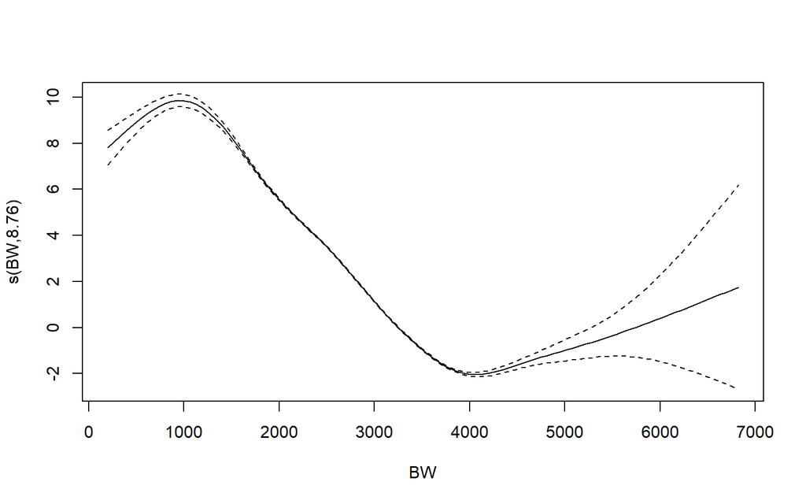

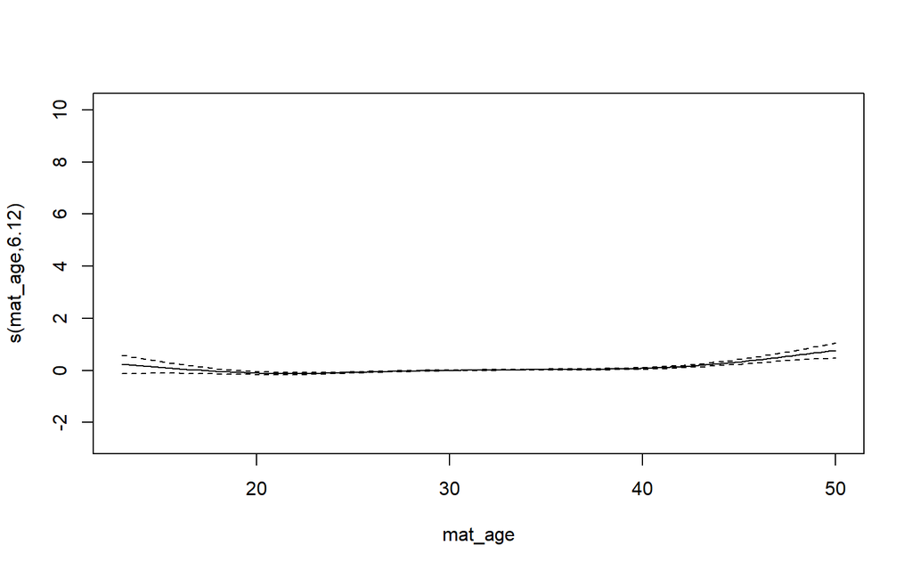